# Analysis of genotype-phenotype associations in BBS

Veronika Niederlova

11 06, 2019

## Summary of the data and descriptive analysis

The data file contains the following variables:

| variables | description |
| --- | --- |
| source | Source study that can be find in the manuscript. |
| source case n. | The ID or another information that can be used for identification of the record within the study. |
| gene | BBS gene that contain causative mutation. |
| sex | Sex of patient, blanks mean not available. |
| age group | Age groups according to age, blanks mean not available. |
| age | Specific age, if available. |
| RD | Retinal dystrophy, 1 = present, 0 = not present, blank = not available |
| OBE | Obesity, 1 = present, 0 = not present, blank = not available |
| PD | Polydactyly, 1 = present, 0 = not present, blank = not available |
| CI | Cognitive impairment, 1 = present, 0 = not present, blank = not available |
| REP | Reproductive system anomalies, 1 = present, 0 = not present, blank = not available |
| REN | Renal anomalies, 1 = present, 0 = not present, blank = not available |
| HEART | Heart anomalies, 1 = present, 0 = not present, blank = not available |
| LIV | Liver anomalies, 1 = present, 0 = not present, blank = not available |
| DD | Developmental delay, 1 = present, 0 = not present, blank = not available |
| muttype | Type of mutation, MSMSandMScLOF meaning missense mutation in at least one allele, cLOF meaning assumed complete loss of function mutations in both alleles |
| sisubset | Severity score subset, yes if information about RD, OBE, PD, CI and REN is stated, no if any of these contain blanks. |
| ggroup | Group of genes according to their function, bbs3 for mutations in BBS3, bbsome for mutations in BBS1, BBS2, BBS4, BBS5, BBS7, BBS8, BBS9 and BBS18, chaps for mutations in BBS6,BBS10 and BBS12, other f… |
| allwow | Yes for canonical BBS genes BBS1-10, BBS12 and BBS18, no for BBS11, BBS13, BBS14, BBS16, BBS17, BBS19, BBS20 and BBS21. |
| canonwobbs1 | Yes for canonical BBS genes other than BBS1 (BBS2-10, BBS12 and BBS18), no for BBS1, BBS11, BBS13, BBS14, BBS16, BBS17, BBS19, BBS20 and BBS21. |
| si | syndromic score calculated as the sum of RD, OBE, PD, CI and REN divided by 5. |
| agegroup | Age groups similar to variable age group renamed as follows: age1 = 0-9, age2 = 10-19, age3 = 20-39, age4 = 40+. |
| year | Year of publication |
| m390r | Indicates if the particular mutation is BBS1 M390R/M390R |

Now let’s calculate the penetrance of mutations in particular genes and particular phenotypes within the whole dataset. These are used in `Figure S2A` and `Figure S2E`.

| gene | count | percentage |
| --- | --- | --- |
| BBS1 | 214 | 23.80 |
| BBS2 | 85 | 9.45 |
| BBS4 | 49 | 5.45 |
| BBS5 | 34 | 3.78 |
| BBS7 | 37 | 4.12 |
| BBS8 | 17 | 1.89 |
| BBS9 | 29 | 3.23 |
| BBS10 | 133 | 14.79 |
| BBS6 | 58 | 6.45 |
| BBS12 | 59 | 6.56 |
| BBS3 | 47 | 5.23 |
| other | 137 | 15.24 |

```
##
##  Pearson's Chi-squared test
##
## data:  penetrance_table
## X-squared = 941.92, df = 8, p-value < 2.2e-16
```

```
## [1] 5.103649e-198
```

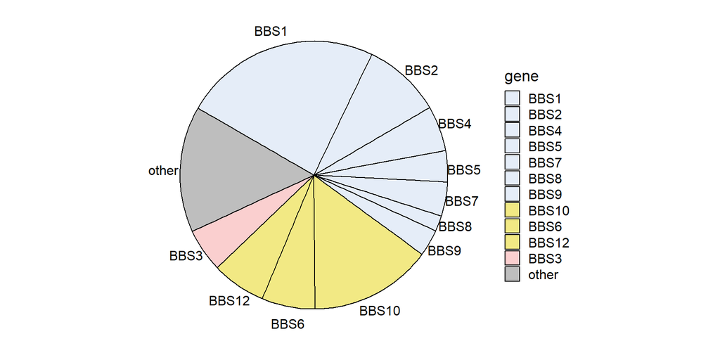

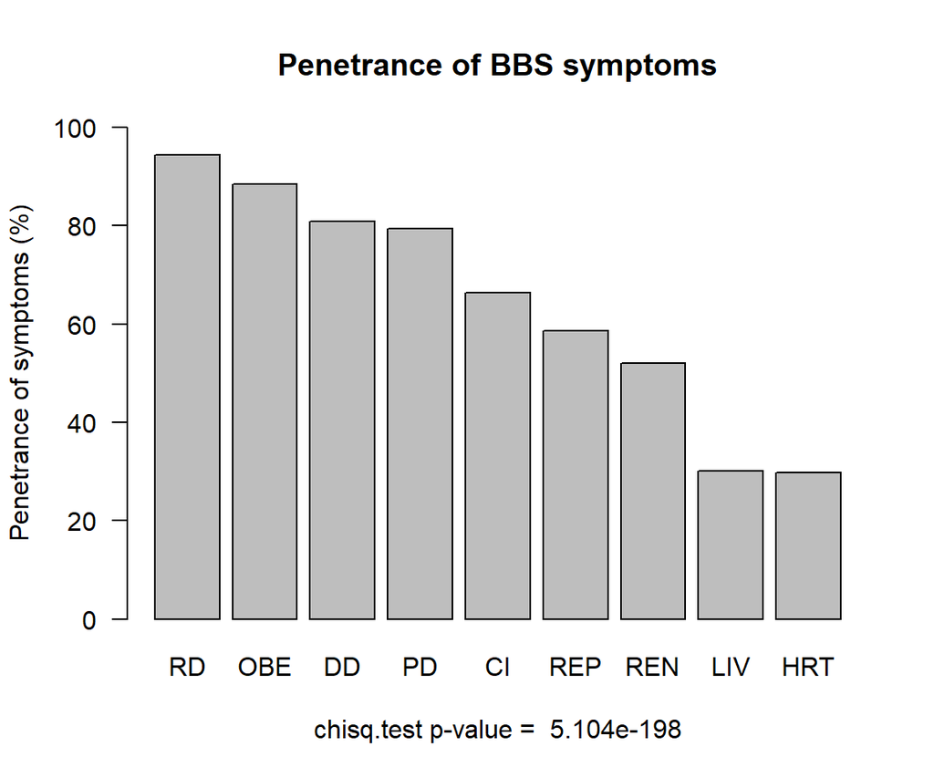

Now, let’s analyze the whole dataset in terms of sex, age and mutation types. This analysis will also be applied to subsets of patients grouped according to the functional groups of BBS genes in which the patients have their causative mutations. These information are provided in Figures S2B-D.

Summary analysis in the whole dataset for `Figure S2B`:

|  | all | bbsome | bbs3 | chaperonins | other |
| --- | --- | --- | --- | --- | --- |
| Number of patients | 899 | 466 | 47 | 250 | 136 |
| Sex information available | 496 | 274 | 28 | 153 | 41 |
| Number of male patients | 257 | 137 | 16 | 88 | 16 |
| Number of female patients | 239 | 137 | 12 | 65 | 25 |
| % of male | 52 | 50 | 57 | 58 | 39 |
| % of female | 48 | 50 | 43 | 42 | 61 |
| Age information available | 475 | 257 | 26 | 149 | 43 |
| Number of age 0-9 years | 67 | 37 | 0 | 25 | 5 |
| Number of age 10-19 years | 155 | 69 | 7 | 60 | 19 |
| Number of age 20-39 years | 187 | 108 | 15 | 48 | 16 |
| Number of age 40+ years | 66 | 43 | 4 | 16 | 3 |
| % of age 0-9 years | 14 | 14 | 0 | 17 | 12 |
| % of age 10-19 years | 33 | 27 | 27 | 40 | 44 |
| % of age 20-39 years | 39 | 42 | 58 | 32 | 37 |
| % of age 40+ years | 14 | 17 | 15 | 11 | 7 |
| Mutation type avaiable | 827 | 437 | 34 | 235 | 121 |
| Number of cLOF | 458 | 233 | 14 | 109 | 102 |
| Number of missense | 369 | 204 | 20 | 126 | 19 |
| % of cLOF mutations | 55 | 53 | 41 | 46 | 84 |
| % of missense mutations | 45 | 47 | 59 | 54 | 16 |

Summary analysis in the bbsome group for `Figure S2C`:

|  | bbsome | bbs1 | bbs2 | bbs4 | bbs5 | bbs7 | bbs8 | bbs9 | bbs18 |
| --- | --- | --- | --- | --- | --- | --- | --- | --- | --- |
| Number of patients | 466 | 214 | 85 | 49 | 34 | 37 | 17 | 29 | 1 |
| Sex information available | 274 | 150 | 39 | 18 | 18 | 22 | 14 | 12 | 1 |
| Number of male patients | 137 | 68 | 23 | 8 | 8 | 15 | 7 | 7 | 1 |
| Number of female patients | 137 | 82 | 16 | 10 | 10 | 7 | 7 | 5 | 0 |
| % of male | 50 | 45 | 59 | 44 | 44 | 68 | 50 | 58 | 100 |
| % of female | 50 | 55 | 41 | 56 | 56 | 32 | 50 | 42 | 0 |
| Age information available | 257 | 140 | 39 | 19 | 11 | 21 | 13 | 13 | 1 |
| Number of age 0-9 years | 37 | 12 | 15 | 3 | 0 | 3 | 1 | 3 | 0 |
| Number of age 10-19 years | 69 | 24 | 11 | 8 | 4 | 11 | 8 | 3 | 0 |
| Number of age 20-39 years | 108 | 67 | 12 | 8 | 5 | 6 | 3 | 7 | 0 |
| Number of age 40+ years | 43 | 37 | 1 | 0 | 2 | 1 | 1 | 0 | 1 |
| % of age 0-9 years | 14 | 9 | 38 | 16 | 0 | 14 | 8 | 23 | 0 |
| % of age 10-19 years | 27 | 17 | 28 | 42 | 36 | 52 | 62 | 23 | 0 |
| % of age 20-39 years | 42 | 48 | 31 | 42 | 45 | 29 | 23 | 54 | 0 |
| % of age 40+ years | 17 | 26 | 3 | 0 | 18 | 5 | 8 | 0 | 100 |
| Mutation type avaiable | 437 | 201 | 84 | 44 | 31 | 36 | 15 | 25 | 1 |
| Number of cLOF | 233 | 70 | 52 | 41 | 21 | 13 | 12 | 23 | 1 |
| Number of missense | 204 | 131 | 32 | 3 | 10 | 23 | 3 | 2 | 0 |
| % of cLOF mutations | 53 | 35 | 62 | 93 | 68 | 36 | 80 | 92 | 100 |
| % of missense mutations | 47 | 65 | 38 | 7 | 32 | 64 | 20 | 8 | 0 |

Summary analysis in the chaperonins group for `Figure S2D`:

|  | all_chaperonins | bbs6 | bbs10 | bbs12 |
| --- | --- | --- | --- | --- |
| Number of patients | 250 | 58 | 133 | 59 |
| Sex information available | 153 | 25 | 95 | 33 |
| Number of male patients | 88 | 14 | 56 | 18 |
| Number of female patients | 65 | 11 | 39 | 15 |
| % of male | 58 | 56 | 59 | 55 |
| % of female | 42 | 44 | 41 | 45 |
| Age information available | 149 | 19 | 94 | 36 |
| Number of age 0-9 years | 25 | 3 | 16 | 6 |
| Number of age 10-19 years | 60 | 7 | 44 | 9 |
| Number of age 20-39 years | 48 | 8 | 26 | 14 |
| Number of age 40+ years | 16 | 1 | 8 | 7 |
| % of age 0-9 years | 17 | 16 | 17 | 17 |
| % of age 10-19 years | 40 | 37 | 47 | 25 |
| % of age 20-39 years | 32 | 42 | 28 | 39 |
| % of age 40+ years | 11 | 5 | 9 | 19 |
| Mutation type avaiable | 235 | 56 | 122 | 57 |
| Number of cLOF | 109 | 15 | 65 | 29 |
| Number of missense | 126 | 41 | 57 | 28 |
| % of cLOF mutations | 46 | 27 | 53 | 51 |
| % of missense mutations | 54 | 73 | 47 | 49 |

## Syndromic score

For the analyses in Figure 1 we use the syndromic score, which is defined in patients with reported presence/absence of the five primary phenotypic criteria (RD,OBE,PD,CI,REN). Patients with blanks in any of these categories are not used for this statistics. Let’s define the syndromic score subset called ’set and analyze the penetrance of the symptoms and penetrance of mutations in BBS genes in this ’set, as used in `Figure 1B` and `Figure 1C`.

| gene | count | percentage |
| --- | --- | --- |
| BBS1 | 117 | 27.46 |
| BBS2 | 33 | 7.75 |
| BBS4 | 22 | 5.16 |
| BBS5 | 18 | 4.23 |
| BBS7 | 27 | 6.34 |
| BBS8 | 11 | 2.58 |
| BBS9 | 13 | 3.05 |
| BBS10 | 72 | 16.90 |
| BBS6 | 27 | 6.34 |
| BBS12 | 32 | 7.51 |
| BBS3 | 32 | 7.51 |
| other | 22 | 5.16 |

```
##
##  Pearson's Chi-squared test
##
## data:  penetrance_table
## X-squared = 460.93, df = 4, p-value < 2.2e-16
```

```
## [1] 1.887449e-98
```

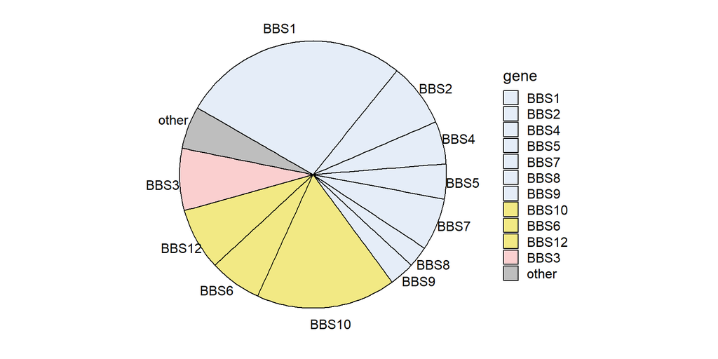

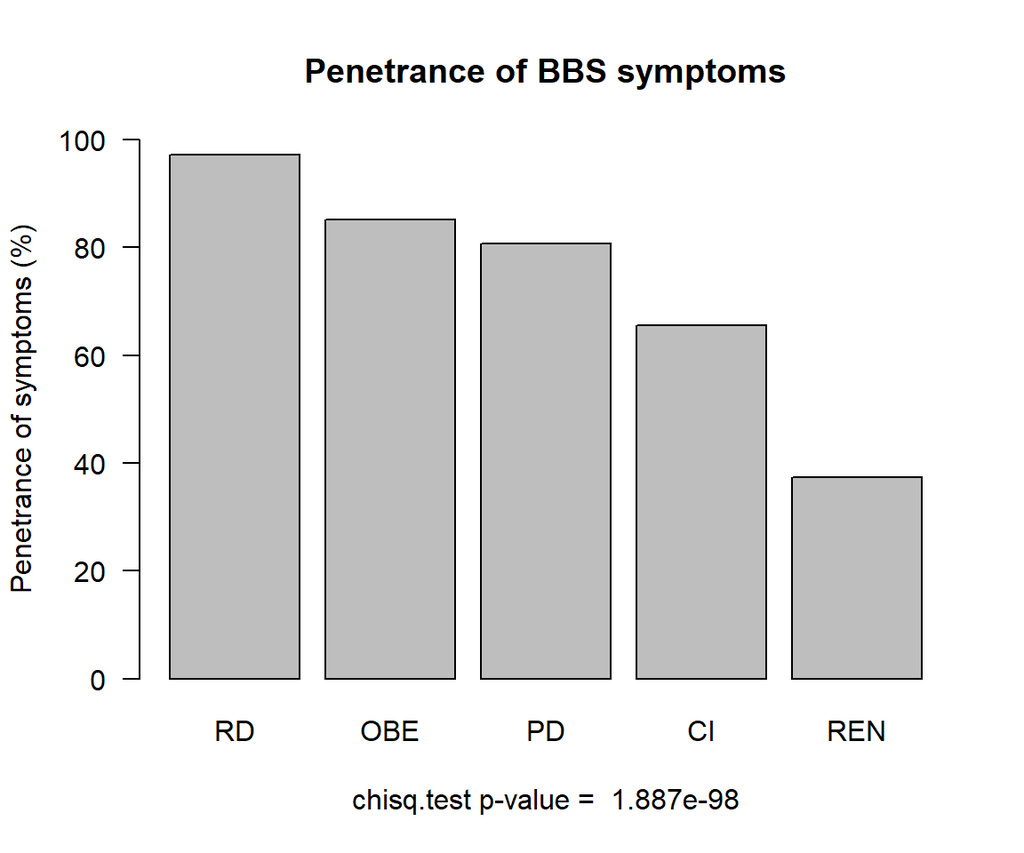

Summary analysis of the syndromic score in the ’set follows. This is used in `Figure S3B`.

|  | set | set_bbsome | set_bbs3 | set_chaperonins | set_other |
| --- | --- | --- | --- | --- | --- |
| Number of patients | 426 | 242 | 32 | 131 | 21 |
| Sex information available | 287 | 165 | 15 | 91 | 16 |
| Number of male patients | 155 | 85 | 6 | 58 | 6 |
| Number of female patients | 132 | 80 | 9 | 33 | 10 |
| % of male | 54 | 52 | 40 | 64 | 38 |
| % of female | 46 | 48 | 60 | 36 | 62 |
| Age information available | 270 | 146 | 15 | 91 | 18 |
| Number of age 0-9 years | 36 | 20 | 0 | 15 | 1 |
| Number of age 10-19 years | 85 | 38 | 2 | 38 | 7 |
| Number of age 20-39 years | 108 | 62 | 12 | 27 | 7 |
| Number of age 40+ years | 41 | 26 | 1 | 11 | 3 |
| % of age 0-9 years | 13 | 14 | 0 | 16 | 6 |
| % of age 10-19 years | 31 | 26 | 13 | 42 | 39 |
| % of age 20-39 years | 40 | 42 | 80 | 30 | 39 |
| % of age 40+ years | 15 | 18 | 7 | 12 | 17 |
| Mutation type avaiable | 418 | 240 | 26 | 131 | 21 |
| Number of cLOF | 202 | 121 | 8 | 62 | 11 |
| Number of missense | 216 | 119 | 18 | 69 | 10 |
| % of cLOF mutations | 48 | 50 | 31 | 47 | 52 |
| % of missense mutations | 52 | 50 | 69 | 53 | 48 |

Histogram plots showing the distribution of syndromic score for `Figure 1D` and `Figure S3A`.

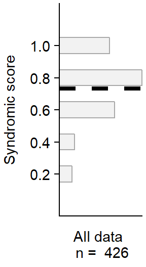

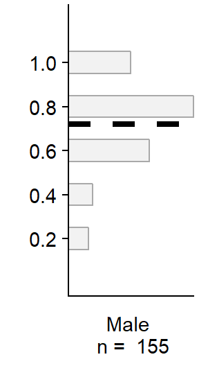

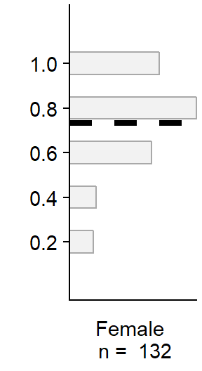

### Syndromic score in patient groups divided according to gene functions

Let’s investigate the severity score between groups of BBS genes based on their functions.

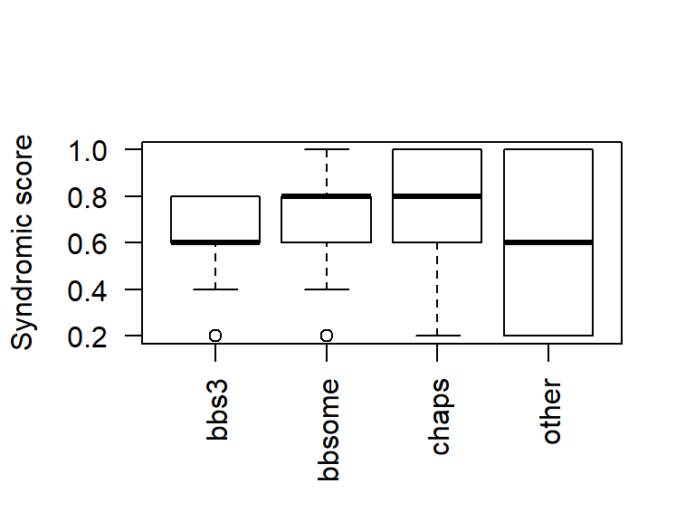

```
##
##  Kruskal-Wallis rank sum test
##
## data:  subset_sscore$si by subset_sscore$ggroup
## Kruskal-Wallis chi-squared = 22.971, df = 3, p-value = 4.095e-05
```

```
##       Comparison         Z      P.unadj        P.adj
## 1  bbs3 - bbsome -3.569741 3.573344e-04 1.786672e-03
## 2   bbs3 - chaps -4.550336 5.356020e-06 3.213612e-05
## 3 bbsome - chaps -2.081703 3.736957e-02 1.121087e-01
## 4   bbs3 - other -1.328062 1.841577e-01 3.683154e-01
## 5 bbsome - other  1.312178 1.894601e-01 1.894601e-01
## 6  chaps - other  2.230545 2.571126e-02 1.028451e-01
```

Histogram plots showing the distribution of syndromic score in different gene groups for `Figure 1E`.

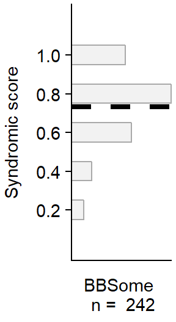

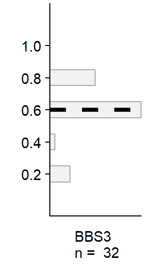

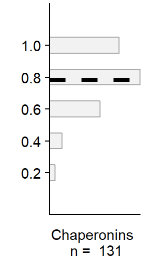

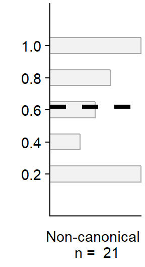

### Syndromic score in patients with different Chaperonin genes mutated

Summary of ’set patients with mutations in chaperonin-encoding BBS genes `Figure S3D`:

|  | all_chaperonins | set_bbs6 | set_bbs10 | set_bbs12 |
| --- | --- | --- | --- | --- |
| Number of patients | 131 | 27 | 72 | 32 |
| Sex information available | 91 | 19 | 55 | 17 |
| Number of male patients | 58 | 10 | 39 | 9 |
| Number of female patients | 33 | 9 | 16 | 8 |
| % of male | 64 | 53 | 71 | 53 |
| % of female | 36 | 47 | 29 | 47 |
| Age information available | 91 | 14 | 57 | 20 |
| Number of age 0-9 years | 15 | 2 | 12 | 1 |
| Number of age 10-19 years | 38 | 7 | 25 | 6 |
| Number of age 20-39 years | 27 | 5 | 13 | 9 |
| Number of age 40+ years | 11 | 0 | 7 | 4 |
| % of age 0-9 years | 16 | 14 | 21 | 5 |
| % of age 10-19 years | 42 | 50 | 44 | 30 |
| % of age 20-39 years | 30 | 36 | 23 | 45 |
| % of age 40+ years | 12 | 0 | 12 | 20 |
| Mutation type avaiable | 131 | 27 | 72 | 32 |
| Number of cLOF | 62 | 6 | 42 | 14 |
| Number of missense | 69 | 21 | 30 | 18 |
| % of cLOF mutations | 47 | 22 | 58 | 44 |
| % of missense mutations | 53 | 78 | 42 | 56 |

Testing if there are differences in the syndromic score between patients with mutations in chpaeronin-encoding genes `Figure 1F`.

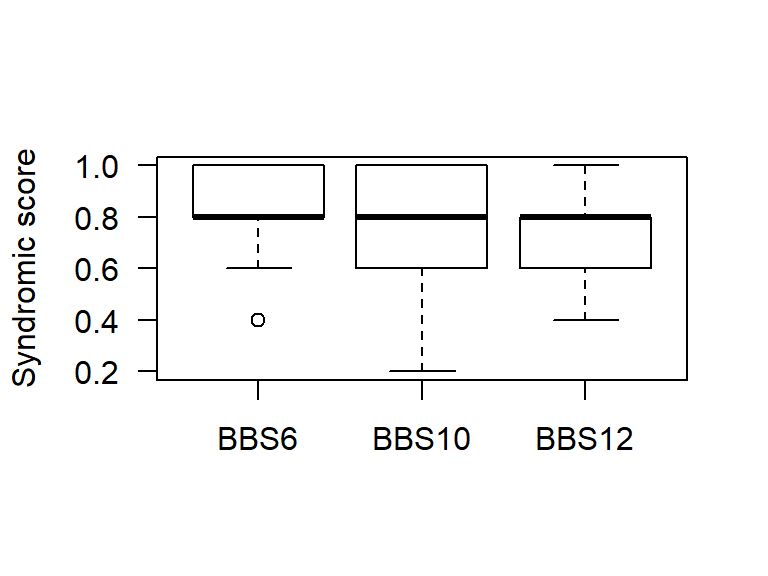

```
##
##  Kruskal-Wallis rank sum test
##
## data:  subset_chaperonins$si by droplevels(subset_chaperonins$gene)
## Kruskal-Wallis chi-squared = 4.0051, df = 2, p-value = 0.135
```

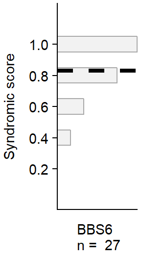

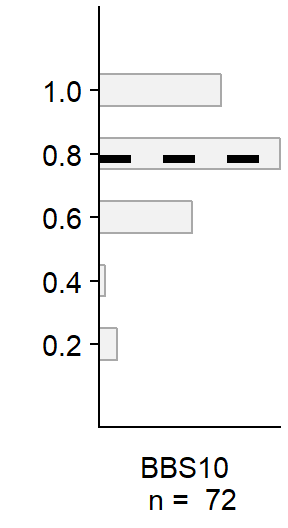

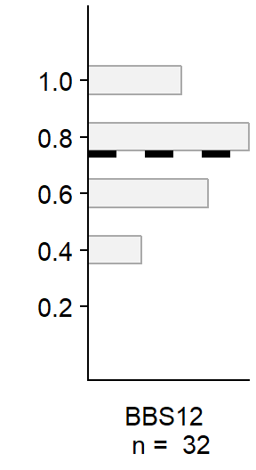

### Syndromic score in patients with different BBSome genes mutated

Summary analysis of the bbsome group of ’set patients `Figure S3C`:

|  | set_bbsome | set_bbs1 | set_bbs2 | set_bbs4 | set_bbs5 | set_bbs7 | set_bbs8 | set_bbs9 | set_bbs18 |
| --- | --- | --- | --- | --- | --- | --- | --- | --- | --- |
| Number of patients | 242 | 117 | 33 | 22 | 18 | 27 | 11 | 13 | 1 |
| Sex information available | 165 | 86 | 24 | 8 | 14 | 16 | 10 | 6 | 1 |
| Number of male patients | 85 | 41 | 14 | 4 | 5 | 11 | 6 | 3 | 1 |
| Number of female patients | 80 | 45 | 10 | 4 | 9 | 5 | 4 | 3 | 0 |
| % of male | 52 | 48 | 58 | 50 | 36 | 69 | 60 | 50 | 100 |
| % of female | 48 | 52 | 42 | 50 | 64 | 31 | 40 | 50 | 0 |
| Age information available | 146 | 70 | 26 | 9 | 7 | 16 | 10 | 7 | 1 |
| Number of age 0-9 years | 20 | 8 | 7 | 2 | 0 | 0 | 1 | 2 | 0 |
| Number of age 10-19 years | 38 | 8 | 9 | 2 | 3 | 9 | 5 | 2 | 0 |
| Number of age 20-39 years | 62 | 34 | 9 | 5 | 2 | 6 | 3 | 3 | 0 |
| Number of age 40+ years | 26 | 20 | 1 | 0 | 2 | 1 | 1 | 0 | 1 |
| % of age 0-9 years | 14 | 11 | 27 | 22 | 0 | 0 | 10 | 29 | 0 |
| % of age 10-19 years | 26 | 11 | 35 | 22 | 43 | 56 | 50 | 29 | 0 |
| % of age 20-39 years | 42 | 49 | 35 | 56 | 29 | 38 | 30 | 43 | 0 |
| % of age 40+ years | 18 | 29 | 4 | 0 | 29 | 6 | 10 | 0 | 100 |
| Mutation type avaiable | 240 | 117 | 33 | 21 | 17 | 27 | 11 | 13 | 1 |
| Number of cLOF | 121 | 37 | 20 | 20 | 12 | 9 | 9 | 13 | 1 |
| Number of missense | 119 | 80 | 13 | 1 | 5 | 18 | 2 | 0 | 0 |
| % of cLOF mutations | 50 | 32 | 61 | 95 | 71 | 33 | 82 | 100 | 100 |
| % of missense mutations | 50 | 68 | 39 | 5 | 29 | 67 | 18 | 0 | 0 |

Testing if there are differences in the syndromic score between groups of ’set patients with mutations in BBSome genes.

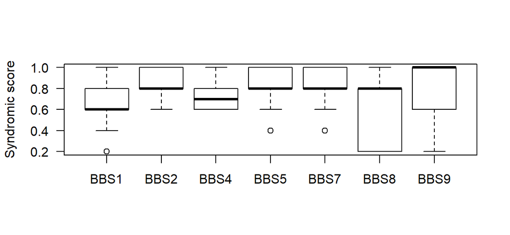

```
##
##  Kruskal-Wallis rank sum test
##
## data:  subset_sscore_bbsome_wobbs18$si by subset_sscore_bbsome_wobbs18$gene
## Kruskal-Wallis chi-squared = 33.33, df = 6, p-value = 9.058e-06
```

```
##     Comparison          Z      P.unadj        P.adj
## 1  BBS1 - BBS2 -3.8096465 1.391656e-04 0.0027833123
## 2  BBS1 - BBS4 -0.6619316 5.080150e-01 1.0000000000
## 3  BBS2 - BBS4  2.1692843 3.006111e-02 0.4208555193
## 4  BBS1 - BBS5 -2.3950749 1.661697e-02 0.2824884936
## 5  BBS2 - BBS5  0.4931479 6.219081e-01 1.0000000000
## 6  BBS4 - BBS5 -1.4239954 1.544478e-01 1.0000000000
## 7  BBS1 - BBS7 -4.3912992 1.126754e-05 0.0002366182
## 8  BBS2 - BBS7 -0.7193219 4.719426e-01 1.0000000000
## 9  BBS4 - BBS7 -2.7287703 6.357096e-03 0.1144277274
## 10 BBS5 - BBS7 -1.0883166 2.764554e-01 1.0000000000
## 11 BBS1 - BBS8  0.1303259 8.963086e-01 0.8963085776
## 12 BBS2 - BBS8  2.2748397 2.291555e-02 0.3666487984
## 13 BBS4 - BBS8  0.5278504 5.976032e-01 1.0000000000
## 14 BBS5 - BBS8  1.6918873 9.066747e-02 1.0000000000
## 15 BBS7 - BBS8  2.7360173 6.218776e-03 0.1181567421
## 16 BBS1 - BBS9 -2.2544410 2.416844e-02 0.3625265574
## 17 BBS2 - BBS9  0.2803607 7.792008e-01 1.0000000000
## 18 BBS4 - BBS9 -1.4443520 1.486400e-01 1.0000000000
## 19 BBS5 - BBS9 -0.1447765 8.848873e-01 1.0000000000
## 20 BBS7 - BBS9  0.8248983 4.094293e-01 1.0000000000
## 21 BBS8 - BBS9 -1.7091482 8.742350e-02 1.0000000000
```

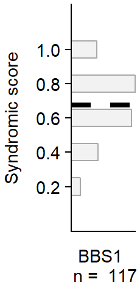

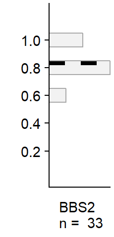

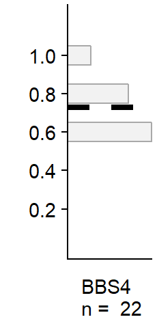

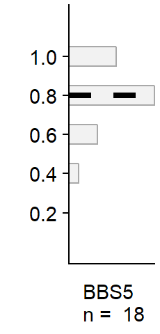

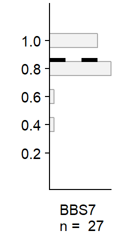

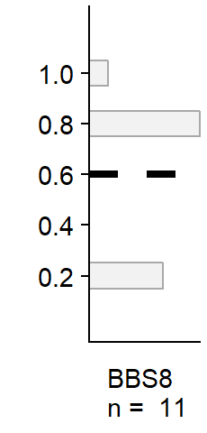

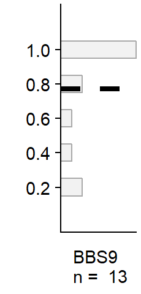

# Syndromic score in patients with cLOF vs MS mutations

Below, we will test if the syndromic score differs between patients with mutations leading to complete loss of function of the protein (such as frameshifts, splicing mutations, large deletions etc.) and patients having at least one missense mutation (either a substitution or a small deletion of one to three amino acids).

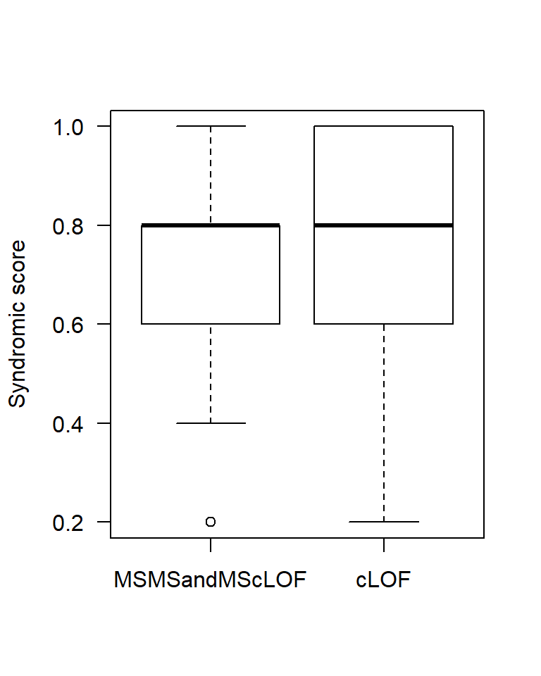

```
##
##  Wilcoxon rank sum test with continuity correction
##
## data:  subset_sscore$si by subset_sscore$muttype
## W = 18032, p-value = 0.001348
## alternative hypothesis: true location shift is not equal to 0
```

In addition, we will test if the proportion of patients with syndromic score of 1 differs between cLOF and missense patients. This will be tested using Fisher test on number of patients with syndromic score 1 or syndromic score other than one in both groups.

```
##
##  Fisher's Exact Test for Count Data
##
## data:
## p-value = 0.005732
## alternative hypothesis: true odds ratio is not equal to 1
## 95 percent confidence interval:
##  0.3197646 0.8458189
## sample estimates:
## odds ratio
##  0.5222815
```

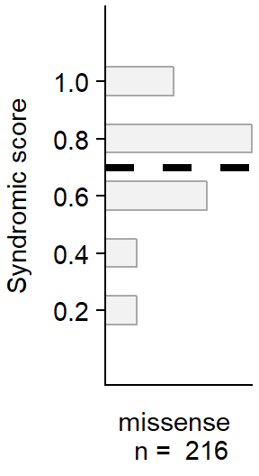

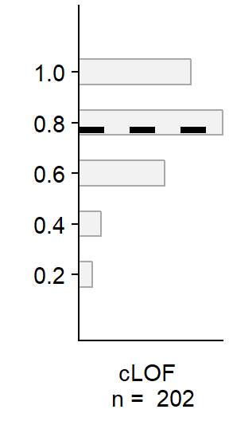

## Syndromic score in cLOF patients

### Patient groups divided according to gene functions

Let’s investigate the severity score between groups of BBS genes based on their functions in the patients with cLOF mutations.

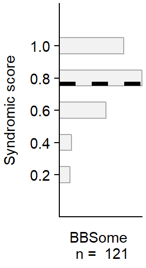

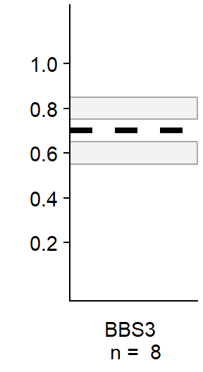

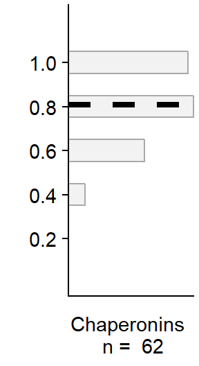

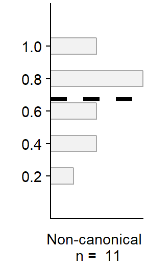

```
##
##  Kruskal-Wallis rank sum test
##
## data:  subset_sscore_cLOF$si by subset_sscore_cLOF$ggroup
## Kruskal-Wallis chi-squared = 5.216, df = 3, p-value = 0.1566
```

```
##       Comparison          Z    P.unadj     P.adj
## 1  bbs3 - bbsome -1.3644814 0.17241610 0.6896644
## 2   bbs3 - chaps -1.7597062 0.07845764 0.4707458
## 3 bbsome - chaps -1.0433956 0.29676509 0.5935302
## 4   bbs3 - other -0.2504791 0.80221688 0.8022169
## 5 bbsome - other  1.2121296 0.22546279 0.6763884
## 6  chaps - other  1.6648501 0.09594266 0.4797133
```